# 7. 序列标注

Natural Language Processing I

7. 序列标注

WU Xiaokun 吴晓堃

xkun.wu [at] gmail

2022/04/08

# 语言序列与标注

## 给每个字一个婉转的音符

> To each word a warbling note.  
> – *A Midsummer Night’s Dream, Act 5, Scene 1*

[figure not shown]

## 陌生词问题

词典随历史不断演化：古文中的未知词问题

> 头上戴着**束发嵌宝紫金冠**，齐眉勒着**二龙戏珠金抹额** –《红楼梦》

但人通常可以**推断**陌生词的大致含义

- “头上戴着”：描述头饰；“冠”：帽子，表身份、地位
- “齐眉”、“抹额”：描述头饰的位置，可能类似导汉巾

**先验知识**：相似语境，语义通常相近

- 通过形象进行**类比**：辅助推断

> 南海龙王敖钦道：“我有一顶**凤翅紫金冠**哩。” –《西游记》

## 从词语到字

词语级别的模型：**低 OOV 召回率**

- 粒度越小：训练集词汇表中越容易出现
- 字级别：更细粒度

字级别的模型：假设能够**识别新词起止范围**，就不局限于词典

- 词典随文本**动态构造**
- 再次印证：分词只是手段，是可选预处理

识别新词可以看成**分类问题**

- 每个字对应一个标签；**连续标签**组合成词

> 头上戴着**束发嵌宝紫金冠**，齐眉勒着**二龙戏珠金抹额** –《红楼梦》

## 词类：历史

最早的西方语法书（大约公元前100年）：希腊语

- 西方语言学术语的源头：附会文明
- **8类词**：名词、动词、代词、介词、副词、连词、分词、冠词
  - 之后2000多年欧洲语法框架的基础

20世纪50年代：从结构主义到**形式文法**

- Chomsky，《句法结构》，转换-生成语法

汉语语法：1898年

- **硬搬西方框架**：“言必称希腊”
  - 新文化运动激进派：废除汉字、“直译欧文句法”
    - 鲁迅：我确实说过，而且是推动者
- 融合新旧思想：**逐步探索**现代中文语法体系

## 中文西化

具体名词做主语；不常用“的”、“地”

```
西化：他的收入的减少改变了他的生活方式。
自然：他因收入减少而改变生活方式。
```

不常用“一”；复数不用“们”；不常用连词；不常用“被”（通常表不幸、贬义）

```
西化：你是一个好人，但同学们都知道，我们不适合。请别悲伤和难过。
自然：我是好人。诸位同学都知道，我被分手了，但我并不悲伤难过。
```

尽量不用介词；不常用“性”；定语短（拆成分句）

```
西化：“在公共场合不准吸烟”是普遍性的和强制性的原则。
自然：“公共场合不准吸烟”是普遍原则，通常强制执行。
```

```
直译：我不能同意得更多。听起来……的样子。
日语：以上。
```

## 词类、命名实体

**词类 Parts Of Speech (POS)**：单词的语法分类，也称**词性**

- 邻接关系：形容词 + 名词，副词 + 动词
- 句法结构：动词依赖于名词

**命名实体 Named Entity (NE)**：描述实体的词汇

- 人名、地点、组织、日期、价格
- 应用：机器问答、语义关系

## 序列标注

**序列标注 sequence labeling**：给每个字一个类别标签

$$f: x_i \mapsto y_i$$

可以看作**有意义地分词**

- POS标注：字（词） $\mapsto$ 划分 + 词类
- 命名实体识别：字（词） $\mapsto$ 划分 + NE类别

## 词类：讨论范畴

词类有**语义倾向**

- 形容词：属性；名词：人、物

NLP中POS主要讨论相邻词之间的**语法关系**

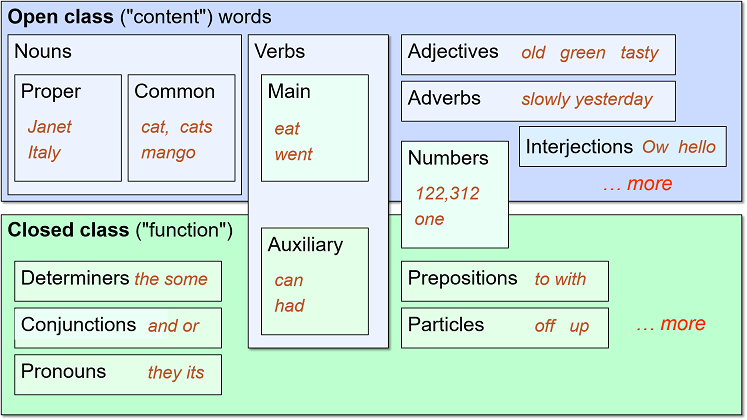

## Penn Treebank 标签集

| Tag | Description | Example | Tag | Description | Example | Tag | Description | Example |
| --- | --- | --- | --- | --- | --- | --- | --- | --- |
| CC | coord. conj. | and, but, or | NNP | proper noun, sing. | IBM | TO | “to” | to |
| CD | cardinal number | one, two | NNPS | proper noun, plu. | Carolinas | UH | interjection | ah, oops |
| DT | determiner | a, the | NNS | noun, plural | llamas | VB | verb | base eat |
| EX | existential ‘there’ | there | PDT | predeterminer | all, both | VBD | verb past tense | ate |
| FW | foreign word | mea culpa | POS | possessive ending | ’s | VBG | verb gerund | eating |
| IN | preposition/subordin-conj | of, in, by | PRP | personal pronoun | I, you, he | VBN | verb past participle | eaten |
| JJ | adjective | yellow | PRP$ | possess. pronoun | your, one’s | VBP | verb | non-3sg-pr |
| JJR | comparative adj | bigger | RB | adverb | quickly | VBZ | verb | 3sg pres |
| JJS | superlative adj | wildest | RBR | comparative adv | faster | WDT | wh-determ. | which, that |
| LS | list item marker | 1, 2, One | RBS | superlatv. adv | fastest | WP | wh-pronoun | what, who |
| MD | modal | can, should | RP | particle | up, off | WP$ | wh-possess. | whose |
| NN | sing or mass noun | llama | SYM | symbol | +,%, & | WRB | wh-adverb | how, where |

## POS标注

**词类 Parts Of Speech (POS)**：单词的语法分类，也称**词性**

POS标注可以看作**消除歧义**的任务

```
Book that flight
Hand me that book
```

```
她希望筹建一所希望小学。
她希望成为全村人的希望。
```

## POS标注：有何用途？

其他NLP任务的预处理

- 句法解析：效能依赖于词类的正确判别
- 机器翻译：语序矫正，如形容词（英语到西班牙语）
- 情感分析：形容词提供直接依据
- 语音助手：动词、形容词
  - 重音，如“object”；声调，如“好”

语言学分析、计算任务

- 语义演化、创新词
  - “生而不有”
- 词义相似度量：同类相似原则

## POS标注：算法准确度

（英语）大概15%的词目是有歧义的

- 但这些词非常常见
  - 从语言演化角度看：人倾向于**给简单词赋予多重含义**
  - 从信息论编码角度看：码越短，频率越高
- 文本中**大概60%**的词是有歧义的

[Wu 2019] Universal Dependency (UD) 树库上的**准确度：97%**

- 英语树库：准确度大致相同，无论什么算法
- [Manning 2011]（英语）人工标注的准确度：97%

结论：算法与人的表现**差不多**，而且**都很好**

- 是因为POS标注比较简单吗？

## POS标注：并不简单

尽管文本中大概60%的词是有歧义的

- 歧义对应的标签：**频率不平衡**
  - 例如：“a”作为冠词的可能性要高得多

### 基准算法

对每个有歧义的词：标注为训练集中**频率最高**的词类

- 基准算法的准确度：92%
  - 算法、人工**只能改进5%**的效能：97%
  - 相对比例：$(97-92)/92 = 5.435\%$

## NE标注

**命名实体 Named Entity (NE)**：描述实体的词汇

- 人名 PER、组织 ORG、地点 LOC、地域 GPE

NE标注可以看作**专有名词的分词**

- 构成专有名词的起止范围 + 标签类型

难点：分割，并识别，即分词的高级任务

- 也称**命名实体识别 Named Entity Recognition (NER)**

## NE标注：BIO

[Ramshaw 1995] 转换成**逐词标注**的任务

- B：一个子序列的开始，可简化
- I：子序列的内部
- O：不在任何子序列里

| 北 | 京 | 大 | 学 | 位 | 于 | 北 | 京 | 市 |
| --- | --- | --- | --- | --- | --- | --- | --- | --- |
| B-ORG | I-ORG | I-ORG | I-ORG | O | O | B-GPE | I-GPE | I-GPE |
| I-ORG | I-ORG | I-ORG | I-ORG | O | O | I-GPE | I-GPE | I-GPE |

扩展标签种类：总共$2n+1$，或$n+1$

# 隐式Markov模型

## 回顾序列标注

序列标注：给每个字一个类别标签

- 将字（词）映射到类别
- 将文字序列映射到**同长度**的标签序列

概率建模：计算$T^N$个**定长标签序列**概率，选出最可能的一个

- 既然是对序列建模：需要表达**链式节点组织关系**
- 整条链有$T^N$种序列选择：等价于每个节点有$T$个**状态选择**

## Markov链

**Markov链**：计算**随机变量序列**的概率

- 状态：随机变量，如气温体感
- 状态集：如{冷、热、暖}

## Markov假设

一阶**Markov假设**：未来的预测与过去无关，只看当前状态

$$P(q_i|q_1..q_{i-1}) = P(q_i|q_{i-1})$$

- $q_1..q_{i}$是状态序列
- 一阶Markov模型：等价于**二元语法**模型

## Markov链：概率

假设**初始概率分布**：$\pi = [0.1,0.7,0.2]$

- 初始最可能的状态：“冷”；概率：$.7$

**转移概率矩阵**：状态变化的概率

- 每行都是可能性集合

|  | 热 | 冷 | 暖 |
| --- | --- | --- | --- |
| **热** | $.6$ | $.1$ | $.3$ |
| **冷** | $.8$ | $.1$ | $.1$ |
| **暖** | $.6$ | $.3$ | $.1$ |

## Markov链：序列概率计算举例

假设**初始概率分布**：$\pi = [0.1,0.7,0.2]$

观测序列：计算连续4天的气温

## Markov链：严格定义

[output not shown]

## 隐变量

Markov链：状态、事件必须**可观测**

- 根据观测结果计算初始、转移概率

实际情况：状态、事件**不能被观测**

- 例如：推断词类标签的概率
- 此类变量称为：**隐 hidden 变量**

## 隐式Markov模型 (HMM)

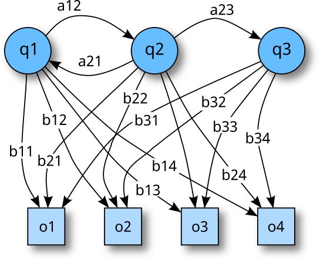

- 隐状态：Markov链，相互转化的**内因**
  - 《扁鹊见蔡桓公》：“**疾**在腠理”，“**病**在骨髓”，常人看不出“健康、疾、病”
- 输出变量：由隐状态直接生成的**表象**，例如发热

问题：**依赖链长**，计算复杂。例如：$(q_1 \rightarrow q_2)_{\times n} \rightarrow q_3 \rightarrow o_4$

- “病入骨髓”需要从健康状态开始计算吗？

## HMM：一阶模型

一阶HMM的两个假设

- 一阶Markov假设：（隐）状态概率只取决于**前一个**（隐）状态
  - 称为**状态转移概率**

$$P(q_i|q_1,..,q_{i-1}) \approx P(q_i|q_{i-1})$$

- 独立性假设：输出变量的概率只取决于**直接关联**的隐状态
  - 称为**观测似然**，或“**发射概率**”

$$P(o_i|q_1,..,q_{T},o_1,..,o_T) \approx P(o_i|q_{i})$$

## HMM：严格定义

[output not shown]

| $O = o_1o_2 ...o_T$ | $T$ **observations**, each one drawn from a vocabulary $V = v_1, v_2,..., v_V$ |
| --- | --- |
| $B = b_i(o_t)$ | **observation likelihoods**, or **emission probabilities**, each expressing the probability of an observation $o_t$ being generated from a state $q_i$ |

## HMM标注器：状态转移概率

**状态转移概率$P(t_i|t_{i-1})$**：标签出现的条件概率

- 例如：$P(名词|形容词)$，$P(动词|副词)$
- 最大似然估计 MLE：标签$t_{i-1}$的邻居中，出现**标签对$(t_{i-1}, t_i)$的可能性**是多少？

$$P(t_i|t_{i-1}) = \frac{\Gamma(t_{i-1}, t_i)}{\Gamma(t_{i-1})}$$

## HMM标注器：观测似然

**观测似然$P(w_i|t_{i})$**：由标签生成词的概率

- 例如：$P(好|形容词)$，$P(快|副词)$
- MLE：假设要生成标签$t_{i}$，**词$w_i$的可能性**是多少？

$$P(w_i|t_{i}) = \frac{\Gamma(t_{i}, w_i)}{\Gamma(t_{i})}$$

- 对比后验$P(t_{i}|w_i)$：**词$w_i$最可能的标签**是什么？
  - 即标注任务的根本目标

## HMM标注器：解码观点

**解码**：给定观测序列，确定隐变量序列；等价于解读未知密码

$$\begin{aligned}
\hat{t}_{1:n} &= \argmax_{t_1..t_n} P(t_1..t_n|w_1..w_n)\\
&= \argmax_{t_1..t_n} P(w_1..w_n|t_1..t_n) P(t_1..t_n)\\
&\approx \argmax_{t_1..t_n} \prod_{i=1}^n \overbrace{P(w_i|t_i)}^{\text{emission}} \overbrace{P(t_i|t_{i-1})}^{\text{transition}}
\end{aligned}$$

反过来即可**生成观测**：例如写作前先构思框架

# HMM：应用

## HMM的基本用法

HMM 的**参数三元组**：$\lambda = (\pi, A, B)$

- 初始概率分布、状态转移矩阵、观测似然矩阵
- 用于**描述隐状态**，例如标签

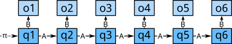

- **生成样本**：$s = \lambda(t;\pi, A, B)$
  - 连续采样生成文本序列$S=s_1..s_n$
- **训练**模型：给定训练集$\{(s^{(i)}, t^{(i)})\}$，估计模型参数$\lambda = (\pi, A, B)$
- **预测**标签：$t = \lambda^{-1}(s) = \argmax_t \lambda(t;\pi, A, B)$
  - 等价于采样$(t, s) \thicksim \lambda$，不区分顺序

## Viterbi 算法

首先计算**状态-观测概率矩阵**

- 每一列：所有可能的标签集合
  - **标签集合**：从词典查出
- 行：单个隐状态，即标签

动态规划：寻找一条**最可能的路径**

## Viterbi 算法：观测似然

|  | Janet | will | back | the | bill |
| --- | --- | --- | --- | --- | --- |
| NNP | 0.000032 | 0 | 0 | 0.000048 | 0 |
| MD | 0 | 0.308431 | 0 | 0 | 0 |
| VB | 0 | 0.000028 | 0.000672 | 0 | 0.000028 |
| JJ | 0 | 0 | 0.000340 | 0 | 0 |
| NN | 0 | 0.000200 | 0.000223 | 0 | 0.002337 |
| RB | 0 | 0 | 0.010446 | 0 | 0 |
| DT | 0 | 0 | 0 | 0.506099 | 0 |

## Viterbi 算法：转移概率

|  | NNP | MD | VB | JJ | NN | RB | DT |
| --- | --- | --- | --- | --- | --- | --- | --- |
| `<s>` | 0.2767 | 0.0006 | 0.0031 | 0.0453 | 0.0449 | 0.0510 | 0.2026 |
| NNP | 0.3777 | 0.0110 | 0.0009 | 0.0084 | 0.0584 | 0.0090 | 0.0025 |
| MD | 0.0008 | 0.0002 | 0.7968 | 0.0005 | 0.0008 | 0.1698 | 0.0041 |
| VB | 0.0322 | 0.0005 | 0.0050 | 0.0837 | 0.0615 | 0.0514 | 0.2231 |
| JJ | 0.0366 | 0.0004 | 0.0001 | 0.0733 | 0.4509 | 0.0036 | 0.0036 |
| NN | 0.0096 | 0.0176 | 0.0014 | 0.0086 | 0.1216 | 0.0177 | 0.0068 |
| RB | 0.0068 | 0.0102 | 0.1011 | 0.1012 | 0.0120 | 0.0728 | 0.0479 |
| DT | 0.1147 | 0.0021 | 0.0002 | 0.2157 | 0.4744 | 0.0102 | 0.0017 |

## 实验：隐式Markov模型

# 条件随机场

## HMM：回顾

HMM计算：本质是**Bayes生成模型**

- 词序列：$S=s_1..s_n$；标签序列：$T=t_1..t_n$

$$\begin{aligned}
\hat{T} &= \argmax_{T} P(S|T) P(T) = \argmax_{T} P(T,S) = \argmax_{T} P(T|S)\\
&= \argmax_{T} \prod_{i} P(s_i|t_i) \prod_{i} P(t_i|t_{i-1})
\end{aligned}$$

## HMM：局限性

HMM 的问题来源于假设的限制，需要足够的**扩充**才能解决实际 NLP 任务

$$\begin{aligned}
\hat{T} &= \argmax_{T} \prod_{i} P(s_i|t_i) \prod_{i} P(t_i|t_{i-1})
\end{aligned}$$

- 独立性假设太强：字之间**并非完全独立**
  - 例如：“蝴”之后几乎一定是“蝶”
- 未知词：创新词的出现远比词典更新频繁
  - 观测与任何隐状态都没有连接：需要**扩充规则集合**
  - 模型必须重建：**似然估计**依赖词典的统计数据

## 从生成模型到判别模型

**生成模型**通常难以直接添加（输出）特征：等价于更新整个模型

$$\hat{c} = \argmax_{c \in C} \overbrace{P(d|c)}^{\text{likelihood}} \overbrace{P(c)}^{\text{prior}}$$

思考：有没有可以灵活添加特征的模型？

有：**判别模型**。例如逻辑回归，将特征看作输入参数

- 可以任意添加、组合特征；但**不能输出序列**

$$\hat{c} = \argmax_{c \in C} \overbrace{P(c|d)}^{\text{posterior}}$$

思考：只要构造出**判别式序列模型**即可解决 HMM 的扩充问题

## 概率图模型

**概率图模型 (PGM)**：用图表示、推断随机变量的**联合概率分布**

- 子图分解：不相关的变量**互不影响计算**
  - 特殊情况：确定性事件阻断传递链

**有向图模型 (DGM)**：按事件的先后顺序连接

- 通常用生成模型实现，例如 HMM
- 分解为条件概率之积：$P(x,y) = \prod_v P(v|\pi(v))$
  - 可以表示**因果推断**

## DGM：因果推断举例

1854年宽街霍乱爆发事件

- “瘴气”理论
- 贫穷、水源、水泵、霍乱

[figure not shown]

## 无向图模型

**无向图模型**：不探究因果关系、不涉及条件概率

- **最大团 clique**：相互关联的随机变量集合，无法继续细分
  - 所有变量两两互联：计算必须同时考虑**所有两两组合**

## 因子图模型

**无向图模型**：不探究因果关系、不涉及条件概率

- **最大团 clique**：相互关联的随机变量集合，无法继续细分
  - 所有变量两两互联：计算必须同时考虑**所有两两组合**

**因子图模型**：因子节点只连接需要计算的变量，描述**实际关联关系**

- 最大团的因子之积：$P(x,y) = \frac{1}{Z} \prod_a \Psi_a(x_a,y_a)$
  - 归一化因子：$Z = \sum_{x,y} \prod_a \Psi_a(x_a,y_a)$

## 条件随机场 CRF

**条件随机场 conditional random field (CRF)**：直接计算后验，判别标签序列

$$\begin{aligned}
\hat{T} &= \argmax_{T \in \mathcal{T}} P(T|S)\\
\end{aligned}$$

- 对比 HMM：$\hat{T} = \argmax_{T} P(S|T) P(T)$

问题：每个时间步都计算**整个标签序列**$T$的概率

- 参考独立性假设：拆解成相关的**局部特征**，然后聚集并归一化

## CRF：严格计算公式

- 首先引入**特征**$F_k(S, T)$：描述序列组合（的可能性）

$$\begin{aligned}
P(T|S) \propto \frac{F_k(S, T)}{\sum_{T'}F_k(S, T')}\\
\end{aligned}$$

- 其次引入**权重**$w_k$：区分不同特征的重要性，例如红色判定红灯

$$\begin{aligned}
P(T|S) \propto \frac{\sum_{k} w_k F_k(S, T)}{\sum_{k,T'} w_k F_k(S, T')}\\
\end{aligned}$$

- 转换成**概率**：类似于sigmoid函数

$$\begin{aligned}
P(T|S) = \frac{\exp \left( \sum_{k=1}^K w_k F_k(S, T) \right)}{\sum_{T' \in \mathcal{T}} \exp \left( \sum_{k=1}^K w_k F_k(S, T') \right)}\\
\end{aligned}$$

## 特征拆解

**全局特征$F_k(S, T)$**：每个都是整个输入序列$S$和输出序列$T$的特征

$$\begin{aligned}
P(T|S) &= \frac{1}{Z(S)} \exp \left( \sum_{k=1}^K w_k F_k(S, T) \right)\\
\end{aligned}$$

- $Z(S) = \sum_{T' \in \mathcal{T}} \exp \left( \sum_{k=1}^K w_k F_k(S, T') \right)$

简化计算：拆解成$T$每个位置上的**局部特征**之和

$$\begin{aligned}
F_k(S, T) &= \sum_{i=1}^n f_k(t_{i-1}, t_i, s_i, i)\\
\end{aligned}$$

- 称为**线性链式CRF**：特征计算只依赖于局部输出$t_{i-1}, t_i$

## CRF：因子图的灵活性

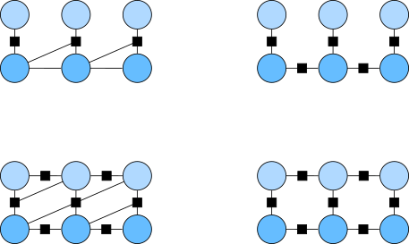

## CRF：推断与训练

$$\begin{aligned}
\hat{T} &= \argmax_{T \in \mathcal{T}} P(T|S)\\
&= \argmax_{T \in \mathcal{T}} \frac{1}{Z(S)} \exp \left( \sum_{k=1}^K w_k F_k(S, T) \right)\\
&= \argmax_{T \in \mathcal{T}} \exp \left( \sum_{k=1}^K w_k \sum_{i=1}^n f_k(t_{i-1}, t_i, s_i, i) \right)\\
&= \argmax_{T \in \mathcal{T}} \sum_{i=1}^n \sum_{k=1}^K w_k f_k(t_{i-1}, t_i, s_i, i)
\end{aligned}$$

- 推断最优标签$\hat{T}$：Viterbi 算法
- 训练参数$w_k$：前向积累、反向传递

# Review

## 本章内容

语言序列与标注。隐式Markov模型 (HMM)。条件随机场 (CRF)。

**重点**：词类、词类标注；命名实体、命名实体识别；一阶HMM的两个基本假设、架构、计算方法；HMM的三种应用方法：采样、训练、预测；线性链式CRF的架构、计算方法。

**难点**：条件随机场 (CRF)的动机；有向图模型与因果推断；因子图模型与最大团。

## 学习目标

- 理解序列标注的两大基本问题：词类标注、命名实体识别
- 理解隐式Markov模型 (HMM)的架构
- 理解一阶HMM的两个基本假设：一阶Markov假设、独立性假设
- 理解一阶HMM的计算方法
- 理解HMM的三种应用方法：采样、训练、预测
- 了解条件随机场 (CRF)的动机：解决HMM模型架构更新难的问题
- 了解有向图模型与因果推断的联系
- 了解因子图模型的动机：描述实际关联关系（而非最大团的全连接）
- 理解线性链式CRF的架构、计算方法

## 问题

简述序列标注任务，及其两大基本问题。

绘图并简述隐式Markov模型 (HMM)的架构。

简述一阶HMM的两个基本假设、架构、计算方法。

简述HMM的三种应用方法。

(*) 简述条件随机场 (CRF)的动机（解决了HMM的什么问题）。

(*) 简述有向图模型与因果推断的联系。

(*) 简述因子图模型的动机（解决了最大团的什么问题）。

简述线性链式CRF的架构、计算方法。